# Bayesian Model Selection and Bayesian Model Averaging

Ivan Aguilar

2021-10-31

```r
library(bayestestR)
library(rstanarm)
library(ggplot2)
library(tidyverse)
library(mombf)
PATH= './bms_bma'
source(file.path(PATH,"routines_seminar1.R"))
source(file.path(PATH, "routines_homework.R"))
set.seed(13)
```

# Objective

1. Load the Vessel data
2. Conduct a prior eliciation to choose $g$
3. Run a Bayesian model selection
4. Obtain predictions by Bayesian Model Averaging
5. Compare to the results obtained with LASSO

# 1. Loading data

```r
data_logx <- log(read_csv(file.path(PATH, "data/Vessel_X.txt"), col_names = FALSE))
dim(data_logx)
```

```
## [1] 180 301
```

```r
data_y <- read_csv(file.path(PATH, "data/Vessel_Y.txt"), col_names = FALSE)
data_y <- data_y[,1]
dim(data_y)
```

```
## [1] 180   1
```

```r
colnames(data_logx)<-sprintf("%s%i","F",seq(100,400,1))
colnames(data_y)<-sprintf("%s%i","Y",seq(1,ncol(data_y)))
data<-cbind(data_logx,data_y)
```

```r
head(data)
```

[output not shown]

[output cut: 251 more lines]

# 2. Prior elicitation to select g

First we create the model matrix

```r
X= model.matrix(~., data=data_logx)
y= data_y
n= nrow(X)
```

and set sequence values of g to try out

```r
gseq= seq(.01,2,length=40)
gseq
```

```
##  [1] 0.01000000 0.06102564 0.11205128 0.16307692 0.21410256 0.26512821
##  [7] 0.31615385 0.36717949 0.41820513 0.46923077 0.52025641 0.57128205
## [13] 0.62230769 0.67333333 0.72435897 0.77538462 0.82641026 0.87743590
## [19] 0.92846154 0.97948718 1.03051282 1.08153846 1.13256410 1.18358974
## [25] 1.23461538 1.28564103 1.33666667 1.38769231 1.43871795 1.48974359
## [31] 1.54076923 1.59179487 1.64282051 1.69384615 1.74487179 1.79589744
## [37] 1.84692308 1.89794872 1.94897436 2.00000000
```

Based on the sequence for g we can now get a prior expectation for Tau, using 1000 simulations for B~N(0,I) (same as in the seminar notes) First we obtain constant denominator value SSE

```r
library(mvtnorm)
V= diag(ncol(X))
beta= rmvnorm(1000, sigma= V) #Simulation for B
sse= colSums((X %*% t(beta))^2) / n #Tau mean denominator for each G
```

and second the prior mean of Tau for each value of g (theoretical r-squared)

```r
r2= double(length(gseq))
for (i in 1:length(gseq)) {
  r2[i]= mean(sse * gseq[i] / (1 + sse * gseq[i]))
}
r2
```

```
##  [1] 0.8828867 0.9573371 0.9719139 0.9787843 0.9828692 0.9856008 0.9875648
##  [8] 0.9890485 0.9902109 0.9911471 0.9919178 0.9925638 0.9931132 0.9935863
## [15] 0.9939981 0.9943599 0.9946803 0.9949660 0.9952224 0.9954538 0.9956638
## [22] 0.9958551 0.9960302 0.9961911 0.9963393 0.9964765 0.9966037 0.9967220
## [29] 0.9968323 0.9969354 0.9970320 0.9971227 0.9972080 0.9972883 0.9973642
## [36] 0.9974359 0.9975038 0.9975682 0.9976294 0.9976875
```

Finally we plot g values vs theoretical r squared

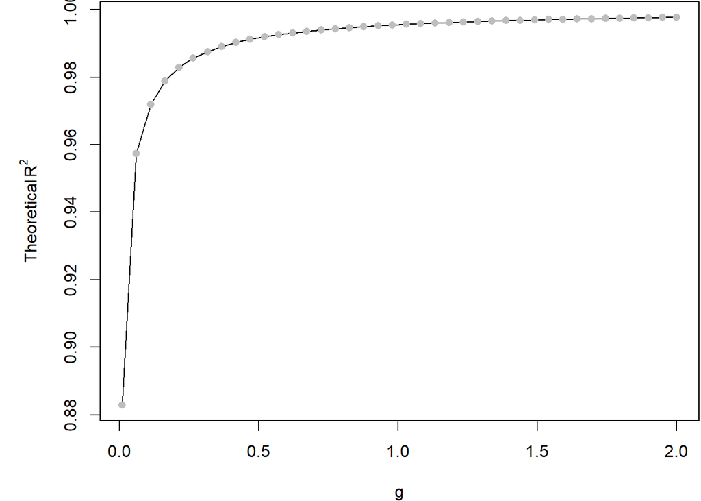

```r
par(mar=c(4,5,.1,.1), cex.lab=1, cex.axis=1)
plot(gseq, r2, type='l', xlab='g', ylab=expression(paste('Theoretical ',R^2)))
points(x=gseq, y=r2, pch = 16, col='gray')
```

# 3. Run a bayesian model selection

Before we start with BMS we initialize a few variables that we will be used during the exercise

```r
y_t= t(y) #Just a transpose of the y
X= data_logx
X= model.matrix(~., data=data_logx)
y= data_y
n= nrow(data_logx)  # No. observations
p= ncol(data_logx)  # No. features
```

## Estimation

On this case we will run the model selection utilizing a Zellner’s prior with g=1 for the coeficients and a beta-binomial prior for the model

```r
fit.bayesreg <- modelSelection(y=y_t, x=X[,-1], priorCoef=zellnerprior(taustd=1), priorDelta=modelbbprior(1,1))
```

```
##  Greedy searching posterior mode... Done.
##  Running Gibbs sampler0%10%20%30%40%50%60%70%80%90%100% Done
```

## Inference

```r
head(postProb(fit.bayesreg),100)
```

```
##                       modelid family          pp
## 1       2,3,5,16,36,58,68,232 normal 0.059391147
## 2       2,3,5,27,36,58,68,232 normal 0.053688632
## 3       2,3,5,15,36,58,68,232 normal 0.042687823
## 4       2,3,5,16,36,61,68,232 normal 0.039546970
## 5       2,3,5,15,36,61,68,232 normal 0.038455287
## 6       2,3,5,27,36,58,68,230 normal 0.028084771
## 7       2,3,5,16,36,58,68,230 normal 0.027322588
## 8       2,3,5,19,36,58,68,232 normal 0.022779817
## 9       2,3,5,27,36,61,68,232 normal 0.021684289
## 10      2,3,5,15,36,58,68,230 normal 0.020002299
## 11      2,3,5,15,36,61,68,230 normal 0.018432315
## 12      2,3,5,16,36,61,68,230 normal 0.018334186
## 13  2,3,5,15,36,58,68,214,230 normal 0.017829343
## 14  2,3,5,15,36,58,68,212,230 normal 0.015264685
```

[output cut: 86 more lines]

## Bayes Model Averaging

After computing the models we can now create a table with the BMA coefficient estimators, posterior intervals and marginal inclusion probabilities

```r
ci.bayesreg <- coef(fit.bayesreg)[-c(1,nrow(coef(fit.bayesreg))),] #Getting coefficients and removing the intercept
#ci.bayesreg <- coef(fit.bayesreg)
sel.bayesreg <- ci.bayesreg[,4, drop=FALSE] > 0.5 #Selected coefficients with marginal inclusion probability > 0.5
ci.bayesreg[,1:3]= round(ci.bayesreg[,1:3], 3)  #Rounding CI
ci.bayesreg[,4]= round(ci.bayesreg[,4], 4)      #Rounding marginal inclusion probability
b= coef(fit.bayesreg)[-c(1,nrow(coef(fit.bayesreg))),1]
```

We can also analyze the number of elements in each model proposed through all iterations

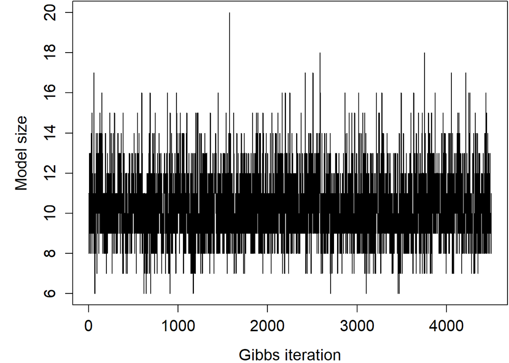

```r
nvars= rowSums(fit.bayesreg$postSample)
par(mar=c(4,5,.1,.1), cex.lab=1.3, cex.axis=1.3)
plot(nvars, type='l', xlab='Gibbs iteration', ylab='Model size')
```

If we now plot the marginal probability for each feature over each iteration we can see how it stabilizes

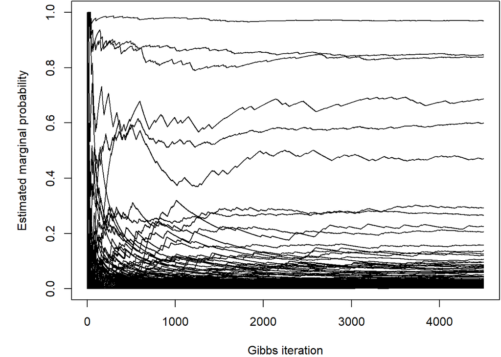

```r
margppest= matrix(NA,nrow=nrow(fit.bayesreg$postSample),ncol=ncol(fit.bayesreg$postSample))
for (j in 1:ncol(fit.bayesreg$postSample)) {
    margppest[,j]= cumsum(fit.bayesreg$postSample[,j])/(1:nrow(fit.bayesreg$postSample))
}

par(mar=c(4,5,.1,.1), cex.lab=1, cex.axis=1)
plot(margppest[,1], type='l', ylim=c(0,1), col='black', xlab='Gibbs iteration', ylab='Estimated marginal probability')
for (j in 2:ncol(margppest)) lines(margppest[,j], col='black')
```

We show the first 10 rows of the model selection output

```r
head(ci.bayesreg,10)
```

```
##      estimate  2.5% 97.5% margpp
## F100    0.014 0.000 0.000 0.1053
## F101    3.267 0.000 4.072 0.6005
## F102    3.676 3.106 5.462 0.8489
## F103    0.184 0.000 3.251 0.2644
## F104    3.576 3.150 4.864 0.9688
## F105    0.000 0.000 0.000 0.0188
## F106    0.000 0.000 0.000 0.0037
## F107    0.000 0.000 0.000 0.0065
## F108    0.000 0.000 0.000 0.0046
## F109   -0.012 0.000 0.000 0.0664
```

But more importantly the same output but for coefficients different from zero

```r
head(ci.bayesreg[ci.bayesreg[,1]!=0,, drop=FALSE],10)
```

```
##      estimate   2.5% 97.5% margpp
## F100    0.014  0.000 0.000 0.1053
## F101    3.267  0.000 4.072 0.6005
## F102    3.676  3.106 5.462 0.8489
## F103    0.184  0.000 3.251 0.2644
## F104    3.576  3.150 4.864 0.9688
## F109   -0.012  0.000 0.000 0.0664
## F114   -0.717 -2.731 0.000 0.1582
## F115   -0.612 -2.525 0.000 0.1377
## F116   -0.060 -1.903 0.000 0.0595
## F117   -0.018  0.000 0.000 0.0437
```

So based on the above let’s quantify the following: - the non-zero coefficients from the BMS/BMA selection - the coefficients with marginal inclusion probability bigger than 0.5, which help us identify the most significant features

```r
#coefficients != 0
sum(ci.bayesreg[,1]!=0)
```

```
## [1] 93
```

```r
#marginal inclusion > 0.5
sum(ci.bayesreg[,4]>0.5)
```

```
## [1] 5
```

```r
ci.bayesreg[ci.bayesreg[,4]>0.5,]
```

```
##      estimate    2.5%  97.5% margpp
## F101    3.267   0.000  4.072 0.6005
## F102    3.676   3.106  5.462 0.8489
## F104    3.576   3.150  4.864 0.9688
## F135   -3.421  -4.067 -2.188 0.8426
## F167  -14.096 -18.275  0.000 0.6864
```

We can also plot the whole set of marginal inclusion probabilities to show all that what we have stated previously

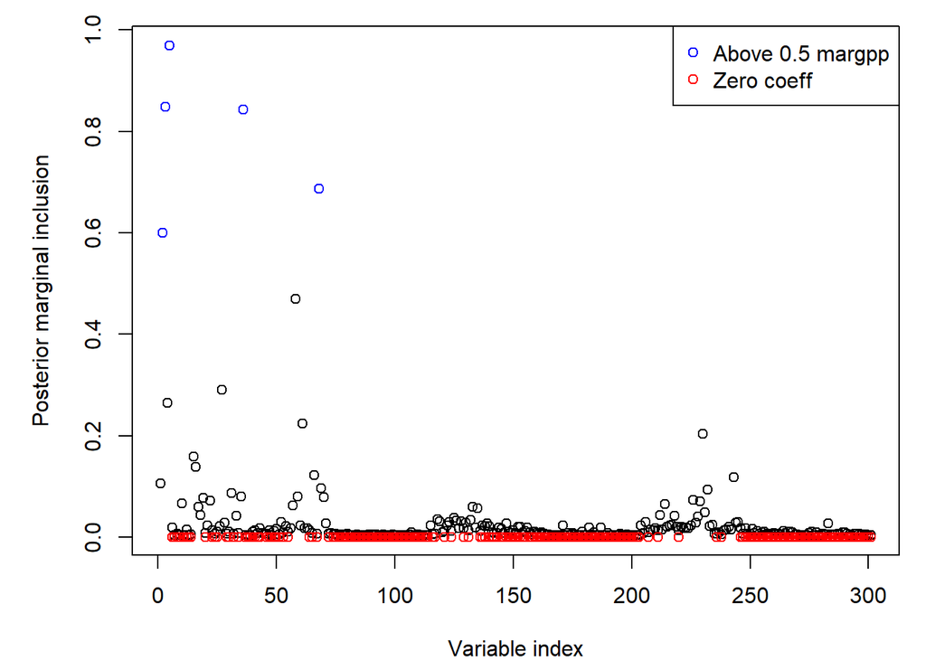

```r
col= rep('black',length(b))
col[b %in% c(-2/3, 1/3, 2/3)]= 'blue'
col[b==1]= 'red'
par(mar=c(4,5,1,1), cex.lab=1, cex.axis=1)
plot(coef(fit.bayesreg)[-c(1,nrow(coef(fit.bayesreg))),'margpp'], col=col, xlab='Variable index', ylab='Posterior marginal inclusion')
points(1:p, ifelse(ci.bayesreg[,1]!=0,NaN,0), pch=1, col='red', ldw=1)
points(1:p, ifelse(ci.bayesreg[,4]>0.5,ci.bayesreg[,4],NaN), pch=1, col='blue', ldw=1)
legend( x="topright",
        legend=c("Above 0.5 margpp","Zero coeff"),
        col=c("blue","red"),
        pch=c(1,1), merge=FALSE )
```

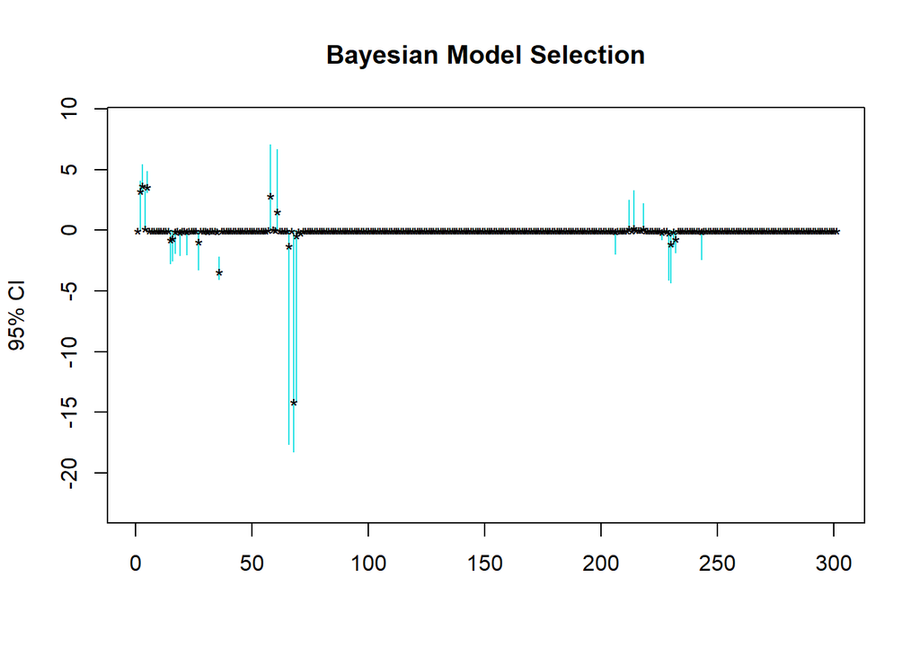

```r
plot(NA, ylim=1.25*range(ci.bayesreg[,1:3]), xlim=c(0,nrow(ci.bayesreg)), ylab='95% CI', xlab='', main='Bayesian Model Selection')
cols= ifelse(beta < ci.bayesreg[ , 1] | beta > ci.bayesreg[, 2], 5, 1)
segments(y0 = ci.bayesreg[, 2], y1 = ci.bayesreg[, 3], x0 = 1:nrow(ci.bayesreg), col = cols)
points(1:p, b, pch = 42, col='black', lwd=1)
```

# 4. Obtaining predictions

```r
#fit.bayesregcv <- kfoldCV.bayes(y=y_t, x=X, K=10, seed = 13)
```

```r
#fit.bayesregcv$pred
```

```r
#as.vector(scale(X[,-1])%*%b + data_logx[,1])
```

```r
#dim(X[,-1])
#length(fit.bayesreg$pred)
#data_logx[,1]
#pred2 = as.vector(X[,-1] %*% b + coef(fit.bayesreg)[1,1])
pred2 = as.vector(X[,-1] %*% b + coef(fit.bayesreg)[1,1])
pred2
```

```
##   [1] 13.7260455 14.5416614 14.5293341 14.8184812 13.9387924 13.6024316
##   [7] 13.6657106 15.3888738 14.0977232 15.9970173 13.8355850 13.8416477
##  [13] 14.3668979 14.0897491 16.4655391 15.0583690 13.8235901 14.3248791
##  [19]  5.8326506  7.5928032  5.4506163  7.4056599  5.6652924  3.9717154
##  [25]  8.1428379  5.0281598  7.0946696  5.8636488  5.4721953  7.1074630
##  [31]  6.0213622  4.1877299  6.8526791 14.5553214 15.4099143 15.3158681
##  [37] 12.4782734 13.9747052 14.7188256 15.2309688 13.8787501 13.8529189
##  [43] 12.5990866 15.2553917 16.2523525 12.8664828 14.0138782 13.6027939
##  [49] 15.3019502 12.9343183 12.4658795 16.2490457 13.8428549 15.6436506
##  [55] 15.6293997 15.4445840  1.2593853  1.5485529  1.3126459  0.5451283
##  [61]  1.2047803  1.1467508  1.2602864  5.7539317  5.9698880  5.8879120
##  [67]  4.7334062  4.2105077  3.4085322  4.5501570  5.6120989  4.1451900
##  [73]  5.6891129  2.1221211  1.2529927  1.2917024 16.4238875 12.6917559
##  [79] 15.1353887 14.4230854 12.8020952 14.8909777 17.3280109 15.8940665
##  [85] 15.5831742 14.4068293 13.2091570 14.4083673 14.0010250 14.3894271
##  [91] 13.8875507 12.6679890 13.7051732 14.1092504 15.1835909 14.6092804
##  [97] 14.4123209 13.4661890 13.5906288 15.6756378 15.5127367 11.9187997
## [103] 12.6869061 15.5310780 16.1439191 14.7449886 14.2647644 14.2246973
## [109]  9.3841199 15.0893299 15.8121471 14.8967284 13.0606115 15.5256505
## [115] 13.7283868 14.3612475 13.0671996 14.5474670 13.0656996 12.1104319
## [121] 14.9533265 15.8514715 16.0565326 13.3156610 10.9909685 11.4606492
## [127] 11.0967656 16.1734567 11.1846666 15.0398394 14.8565107 16.7246620
## [133] 16.8865159 16.6905154 11.9570126 13.5350695 14.9504626 14.2277710
## [139] 11.9810791 14.8149773 16.5705563 14.9243867 14.0621693 15.9069980
## [145] 15.6977630 14.8275819 15.1073940 15.8406223 13.4142314 14.6499016
## [151] 15.3269479 12.1294579 15.7748146 13.9849486 16.2069673 15.4530956
## [157] 16.0521125 14.4456227 15.4342434 15.3624482 15.6004919 15.2968892
## [163] 15.2237370 15.9843049 12.4904202 15.2512813 14.3804090 12.0592727
## [169] 15.5266809 14.2853398 16.0378590 15.4969197 15.5166099 15.3046286
## [175] 11.0411932 11.4946852 11.1689632 14.9963420 11.9883972 14.0374908
```

We then calculate the accuracy of our model vs the original y and we can see that is quite good

```r
r2.bayes= as.vector(cor(data_y,pred2)^2)
r2.bayes
```

```
## [1] 0.9872101
```

# 5. Comparison with Lasso

Now having a look at the previous analysis we did of the vessel dataset with lasso, we can compare BMS/BMA vs Lasso. So let’s recap what we found with Lasso.

First we fit the lasso

```r
library(glmnet)
fit.lasso= cv.glmnet(x=as.matrix(data_logx), y=data_y$Y1, nfolds=10)
fit.lasso
```

```
##
## Call:  cv.glmnet(x = as.matrix(data_logx), y = data_y$Y1, nfolds = 10)
##
## Measure: Mean-Squared Error
##
##      Lambda Index Measure      SE Nonzero
## min 0.03762   100  0.4752 0.05977      31
## 1se 0.04973    94  0.5315 0.06620      29
```

The non-zero coefficients from Lasso are much less than Bayes

```r
b.lasso <- as.vector(coef(fit.lasso, s='lambda.min'))
names(b.lasso) <- c('intercept',colnames(data_logx))
sum(b.lasso!=0) #Lasso
```

```
## [1] 32
```

```r
sum(ci.bayesreg[,1]!=0) #Bayes
```

```
## [1] 93
```

But our r-squared scores is a bit better with Bayes

```r
cv.lassobic= kfoldCV.lasso(x=as.matrix(data_logx), y=data_y$Y1,K=10,seed=1,criterion="cv")
```

```
## Starting cross-validation..........
```

```r
r2.lassobic= cor(data_y$Y1,cv.lassobic$pred)^2
r2.lassobic
```

```
## [1] 0.9773764
```

```r
r2.bayes
```

```
## [1] 0.9872101
```

The above could mean that the penalization from lasso is punishing also the accuracy. In general we see that both models agree in a large majority of the coefficients being set to zero or close to zero. On this point several coefficients have been pushed to zero on the lasso case and not with Bayes, where they remain small but not zero, as we can see in the graph below.

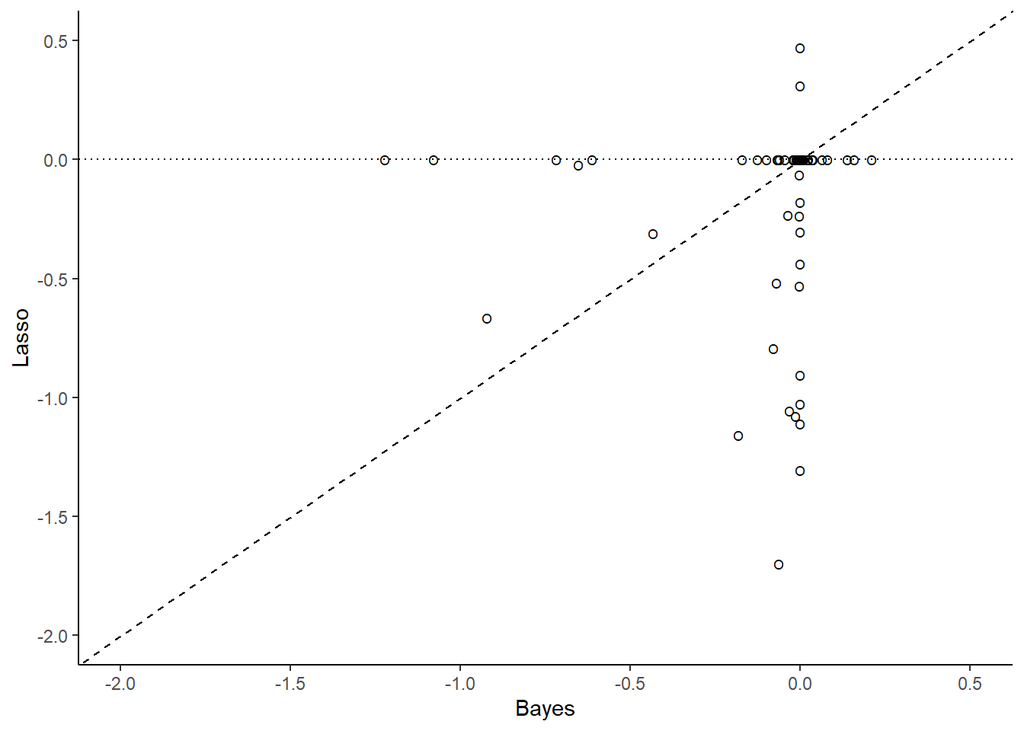

```r
data.frame(bayes= ci.bayesreg[,1], lasso= b.lasso[-1] ) %>%
  ggplot(aes(x=bayes,y=lasso)) +
  geom_point(shape = "O",size=2) +
  geom_abline(slope=1, intercept = 0, linetype = 'dashed') +
  geom_hline(yintercept = 0, linetype = 'dotted') +
  xlab('Bayes') +
  ylab('Lasso') +
  coord_cartesian(xlim=c(-2,0.5),ylim=c(-2,0.5)) +
  theme_classic()
```

Finally let’s plot the coefficients of Bayes and Lasso together where we can confirm the general agreement, but in larger coefficients where Bayes and Lasso agree, Bayes tends to me make the coefficient larger, therefore highlighting more its importance

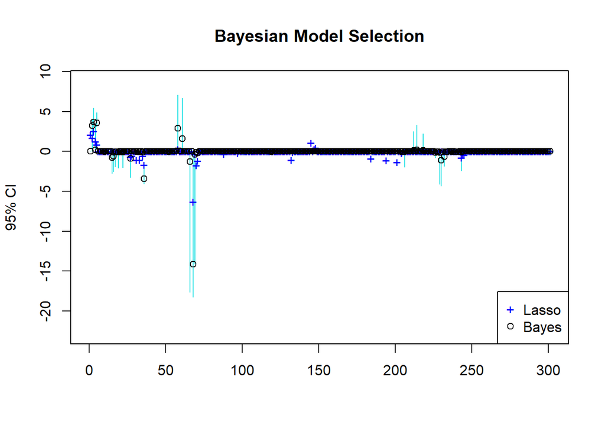

```r
plot(NA, ylim=1.25*range(ci.bayesreg[,1:3]), xlim=c(0,nrow(ci.bayesreg)), ylab='95% CI', xlab='', main='Bayesian Model Selection')
cols= ifelse(b< ci.bayesreg[ , 1] | b > ci.bayesreg[, 2], 5, 1)
segments(y0 = ci.bayesreg[, 2], y1 = ci.bayesreg[, 3], x0 = 1:nrow(ci.bayesreg), col = cols)

points(1:p, b.lasso[-1], pch = 43, col='blue', lwd=1) #Lasso points
points(1:p, b, pch = 21, col='black', lwd=1) #BMA points
legend( x="bottomright",
        legend=c("Lasso","Bayes"),
        col=c("blue","black"),
        pch=c(43,21), merge=FALSE )
```